# Analysis of Environmental Data - Lab Exercise #10

Sarah Guitart

Collaborating Students: None

### Q1

*Submit the code you used to build your ANOVA by hand. Make sure you use the code template so that you use the same variable names as those which we’ll use for the grading.*

```r
library(here)
rope <- read.csv(here("data", "rope.csv"))
head(rope)
```

|  | blade | rope.type | p.cut | p.strength | ch1 | ch2 | ch3 |
| --- | --- | --- | --- | --- | --- | --- | --- |
| 1 | F2 | VEL | 1.00 | 1.00 | 1.59 | 2.60 | 2.53 |
| 2 | F2 | BLAZE | 1.00 | 1.00 | 1.52 | 2.16 | 2.54 |
| 3 | SI | BLAZE | 1.00 | 1.00 | 1.89 | 1.99 | 2.54 |
| 4 | F2 | BLAZE | 0.99 | 0.97 | 1.79 | 2.25 | 2.84 |
| 5 | F2 | VEL | 0.71 | 0.87 | 1.74 | 1.63 | 2.65 |
| 6 | SI | SB | 0.67 | 0.89 | 1.74 | 1.54 | 2.62 |

```r
dim(rope)
```

```
[1] 121   7
```

```r
str(rope)
```

```
'data.frame':   121 obs. of  7 variables:
 $ blade     : chr  "F2" "F2" "SI" "F2" ...
 $ rope.type : chr  "VEL" "BLAZE" "BLAZE" "BLAZE" ...
 $ p.cut     : num  1 1 1 0.99 0.71 0.67 0.65 0.62 0.58 0.57 ...
 $ p.strength: num  1 1 1 0.97 0.87 0.89 0.54 0.55 0.8 0.65 ...
 $ ch1       : num  1.59 1.52 1.89 1.79 1.74 1.74 1.9 2.15 1.86 1.69 ...
 $ ch2       : num  2.6 2.16 1.99 2.25 1.63 1.54 2.31 2.55 1.97 2.61 ...
 $ ch3       : num  2.53 2.54 2.54 2.84 2.65 2.62 2.62 3.38 2.09 1.78 ...
```

```r
sum(is.na(rope))
```

```
[1] 0
```

```r
unique(rope$rope.type)
```

```
[1] "VEL"   "BLAZE" "SB"    "XTC"   "PI"    "BS"
```

```r
rope$rope.type <- as.factor(rope$rope.type)
str(rope)
```

```
'data.frame':   121 obs. of  7 variables:
 $ blade     : chr  "F2" "F2" "SI" "F2" ...
 $ rope.type : Factor w/ 6 levels "BLAZE","BS","PI",..: 5 1 1 1 5 4 5 6 6 5 ...
 $ p.cut     : num  1 1 1 0.99 0.71 0.67 0.65 0.62 0.58 0.57 ...
 $ p.strength: num  1 1 1 0.97 0.87 0.89 0.54 0.55 0.8 0.65 ...
 $ ch1       : num  1.59 1.52 1.89 1.79 1.74 1.74 1.9 2.15 1.86 1.69 ...
 $ ch2       : num  2.6 2.16 1.99 2.25 1.63 1.54 2.31 2.55 1.97 2.61 ...
 $ ch3       : num  2.53 2.54 2.54 2.84 2.65 2.62 2.62 3.38 2.09 1.78 ...
```

```r
levels(rope$rope.type)
```

```
[1] "BLAZE" "BS"    "PI"    "SB"    "VEL"   "XTC"
```

```r
n_obs <- nrow(rope)
n_obs
```

```
[1] 121
```

```r
dim(rope)
```

```
[1] 121   7
```

```r
n_groups <- nlevels(rope$rope.type)
n_groups
```

```
[1] 6
```

```r
mean_cut <- mean(rope$p.cut)
mean_cut
```

```
[1] 0.2804959
```

```r
sum_of_squares <- function(n)
{
  (sum((n - mean_cut)^2))
}
ss_tot <- sum_of_squares(rope$p.cut)
agg_resids <-aggregate(
  x = rope$p.cut,
  by = list(rope$rope.type),
  FUN = function(x) x-mean(x))
agg_sum_sq_resids <-aggregate(
  x = rope$p.cut,
  by = list(rope$rope.type),
  FUN = function(x) sum((x-mean(x))^2))
ss_within <- sum(agg_sum_sq_resids$x)
ss_among <- ss_tot - ss_within
df_tot <- n_obs - 1
df_within <- n_obs - n_groups
df_among <- n_groups - 1
ms_among <- ss_among/df_among
ms_within <- ss_within/df_within
f_ratio <- ms_among / ms_within
f_pval <- 1-pf(f_ratio, df1 = df_among, df_within)
```

Self-test

```r
# number comparison tolerance
digits_check = 5
# Build the reference model using R functions
fit_1 = lm(p.cut ~ rope.type, data=rope)
anova(fit_1)
```

```
Analysis of Variance Table

Response: p.cut
           Df Sum Sq  Mean Sq F value  Pr(>F)
rope.type   5 0.4729 0.094577  2.2312 0.05582 .
Residuals 115 4.8747 0.042389
---
Signif. codes:  0 ‘***’ 0.001 ‘**’ 0.01 ‘*’ 0.05 ‘.’ 0.1 ‘ ’ 1
```

```r
anova_fit_1 = anova(fit_1)
# Check degrees of freedom
anova_fit_1$Df == c(df_among, df_within)
```

```
[1] TRUE TRUE
```

```r
# Check sums of squares
round(anova_fit_1$`Sum Sq`, digits = digits_check) == round(c(ss_among, ss_within), digits = digits_check)
```

```
[1] TRUE TRUE
```

```r
# Check mean squares
round(anova_fit_1$`Mean Sq`, digits = digits_check) == round(c(ms_among, ms_within), digits = digits_check)
```

```
[1] TRUE TRUE
```

```r
# Check the F-ratio
round(anova_fit_1$`F value`[1], digits = digits_check) == round(f_ratio, digits = digits_check)
```

```
[1] TRUE
```

```r
# Check the F test statistic p-value
round(anova_fit_1$`Pr(>F)`[1], digits = digits_check) == round(f_pval, digits = digits_check)
```

```
[1] TRUE
```

### Q2

*Examine the conditional boxplot in the Partitioning Variance: Within-Group section of the walkthrough. Based on the figure, do you think there are equal variances among the groups?*

A: Based on the boxplot in that section of the walkthrough, I don’t think there are equal variances among the rope type groups.

### Q3

*Conduct a Bartlett test to assess the homogeneity of variances of the percent cut among the rope type groups.*

```r
rope_bart <- bartlett.test(p.cut ~ rope.type, data = rope)
rope_bart
```

```
    Bartlett test of homogeneity of variances

data:  p.cut by rope.type
Bartlett's K-squared = 19.687, df = 5, p-value = 0.00143
```

### Q4

*Given your graphical assessment (question 2) and the Bartlett test, do you think an ANOVA-type analysis is appropriate on the raw data? Explain why or why not.*

A: Given my graphical assessment and the Bartlett test, there is likely at least one rope type group whose variance is not equal to the other rope types. This is because some of our groups showed larger spread and our p-value was 0.0014302, meaning that we can reject the null hypothesis that the variances are equal between the groups.

### Q5

*Which rope type is the base case?*

A: BLAZE is the base case for this ANOVA model.

```r
unique(rope$rope.type)
```

```
[1] VEL   BLAZE SB    XTC   PI    BS
Levels: BLAZE BS PI SB VEL XTC
```

```r
fit_rope_1 = lm(p.cut ~ rope.type, data = rope)
summary(fit_rope_1)
```

```
Call:
lm(formula = p.cut ~ rope.type, data = rope)

Residuals:
    Min      1Q  Median      3Q     Max
-0.2800 -0.1500 -0.0355  0.1030  0.6500

Coefficients:
             Estimate Std. Error t value Pr(>|t|)
(Intercept)   0.36714    0.04493   8.172 4.45e-13 ***
rope.typeBS  -0.13014    0.06433  -2.023  0.04538 *
rope.typePI  -0.18014    0.06433  -2.800  0.00599 **
rope.typeSB  -0.09514    0.06433  -1.479  0.14186
rope.typeVEL -0.01714    0.06433  -0.266  0.79033
rope.typeXTC -0.10164    0.06433  -1.580  0.11683
---
Signif. codes:  0 ‘***’ 0.001 ‘**’ 0.01 ‘*’ 0.05 ‘.’ 0.1 ‘ ’ 1

Residual standard error: 0.2059 on 115 degrees of freedom
Multiple R-squared:  0.08843,   Adjusted R-squared:  0.0488
F-statistic: 2.231 on 5 and 115 DF,  p-value: 0.05582
```

### Q6

*What is the mean percent cut of the base case rope? Show your calculation using value(s) from the model coefficient table.*

A: The mean percent cut of the base case rope is 0.367.

```r
base <- round(fit_rope_1$coefficients[1] + 0, digits = 3)
```

### Q7

*What is the mean percent cut rope type XTC? Show your calculation using value(s) from the model coefficient table.*

A: The mean percent cut of the rope type XTC is 0.265.

```r
fit_rope_1$coefficients[6]
```

```
rope.typeXTC
  -0.1016429
```

```r
xtc <- base + round(fit_rope_1$coefficients[6], digits = 3)
```

### Q8

*Use the residuals() function to retrieve the residuals from your model and perform an overall normality test. Report the p-value.*

A: The p-value of our normality test of the model residuals is 7.2377199^{-7}.

```r
overall_resids <- residuals(fit_rope_1)
model_shapiro <- shapiro.test(overall_resids)
```

### Q9

*Do your model residuals meet the normality assumption, and how do you know?*

A: My model residuals do not meet the normality assumption, because our p-value is less than 0.05. This means we can reject the null hypothesis that our residuals are normally distributed.

### Q10

*Perform normality tests on the residuals within each group. How many groups meet the normality assumption? Optional challenge: identify which rope types meet the assumption.*

A: Only three groups meet the normality assumption. They are the BS, PI, and SB rope types.

```r
blaze_resids <- unlist(agg_resids$x[1])
bs_resids <- unlist(agg_resids$x[2])
pi_resids <- unlist(agg_resids$x[3])
sb_resids <- unlist(agg_resids$x[4])
vel_resids <- unlist(agg_resids$x[5])
xtc_resids <- unlist(agg_resids$x[6])
shapiro.test(blaze_resids)
```

```
    Shapiro-Wilk normality test

data:  blaze_resids
W = 0.79481, p-value = 0.0005471
```

```r
shapiro.test(bs_resids)
```

```
    Shapiro-Wilk normality test

data:  bs_resids
W = 0.92292, p-value = 0.1128
```

```r
shapiro.test(pi_resids)
```

```
    Shapiro-Wilk normality test

data:  pi_resids
W = 0.92594, p-value = 0.129
```

```r
shapiro.test(sb_resids)
```

```
    Shapiro-Wilk normality test

data:  sb_resids
W = 0.91358, p-value = 0.0746
```

```r
shapiro.test(vel_resids)
```

```
    Shapiro-Wilk normality test

data:  vel_resids
W = 0.90171, p-value = 0.0444
```

```r
shapiro.test(xtc_resids)
```

```
    Shapiro-Wilk normality test

data:  xtc_resids
W = 0.88636, p-value = 0.02307
```

### Q11

*Given the results of your tests for residual normality, do you think that a one-way Analysis of Variance is appropriate for this dataset?*

A: Given the tests for residual normality, both of the overall model and the different groups, a one-way Analysis of Variance may not be appropriate for this dataset. The overall model and half of the rope type groups had a p-value less than 0.05, which rejects the null hypothesis that our residuals are normally distributed.

### Q12

*Create a conditional boxplot of the female penguins: body mass conditioned on species.*

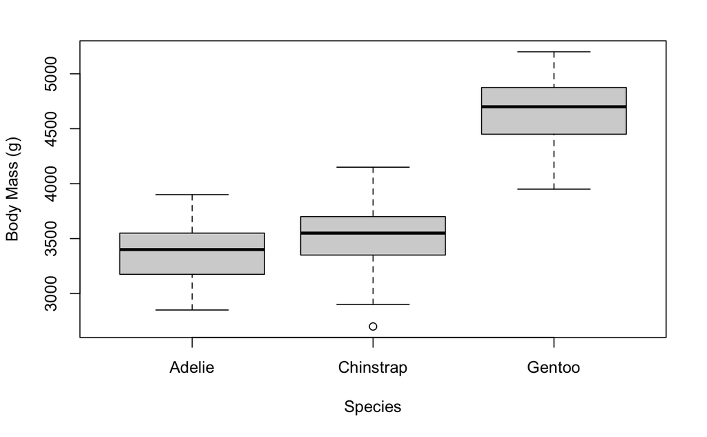

```r
require(palmerpenguins)
pen_fem = subset(penguins, sex == "female")
boxplot(body_mass_g ~ species, data = pen_fem, xlab = "Species", ylab = "Body Mass (g)")
```

### Q13

*Based on the boxplot, do you anticipate any problems with residual normality, or homogeneity of variances? Why or why not?*

A: Based on the boxplot, I anticipate that I will have problems with homogeneity of variances. This because the width of the boxes and the spread of the data look a little different between species.

### Q14

*Conduct a Bartlett test for homogeneity of variances of body mass grouped by species. Hint: use the formula notation. Report the p-value. Is the homogeneity assumption met? Why or why not?*

A: The homogeneity assumption has been met because the p-value for our Bartlett test is 0.9056151, which is greater than 0.05 and does not reject the null hypothesis that the variances between groups are the same.

```r
pen_bart <- bartlett.test(body_mass_g ~ species, data = pen_fem)
```

### Q15

*Fit a linear model of body mass (the response) and species (the predictor) using the female penguin data. Conduct a test for normality of the residuals. Report the p-value. Is the residual normality assumption met? Why or why not?*

A: The p-value for our normality test of the linear model residuals is 0.3638827. This means that the residual normality assumption is met because it is over 0.05, meaning that we cannot reject the null hypothesis that the residuals are normally distributed.

```r
fit_pen <- lm(body_mass_g ~ species, data = pen_fem)
pen_resids <- residuals(fit_pen)
pen_shapiro <- shapiro.test(pen_resids)
```

### Q16

*Conduct a Tukey HSD post-hoc test on your model. Which pair or pairs of species have significantly different body masses?*

A: All pairs of penguin species have significantly different body masses.

```r
pen_hsd = TukeyHSD(aov(fit_pen))
class(pen_hsd)
```

```
[1] "TukeyHSD"  "multicomp"
```

```r
round(pen_hsd$species, digits = 4)
```

```
                      diff       lwr       upr  p adj
Chinstrap-Adelie  158.3703   22.3208  294.4197 0.0179
Gentoo-Adelie    1310.9058 1195.6491 1426.1624 0.0000
Gentoo-Chinstrap 1152.5355 1011.0062 1294.0648 0.0000
```

### Q17

*Describe how your HSD test results match, or do not match, the graphical insight from the conditional boxplot.*

A: The HSD test results somewhat match the graphical insights from the conditional boxplot. From the boxplot, it looks like Gentoos will be significantly larger than both Adelie and Chinstrap penguins. This is reflected in our HSD test too. However, I could assume from our boxplot that Chinstraps might be typically larger than Adelie penguins, but I couldn’t say if they were significantly larger. From our HSD test, we can determine that Chinstrap penguins are larger than Adelie penguins.